# SageMaker Model Quality Report

This report contains model insights and model quality information for candidate **automl-dm-1686442502mz14M1LlWIif-003-3edcf70f**. The candidate was generated by the AutoML job **automl-dm-1686442502**.

The **automl-dm-1686442502mz14M1LlWIif-003-3edcf70f** candidate is a trained **MulticlassClassification** model whose objective is to **Maximize** the **"ACCURACY"** quality metric.

## Contents

1. Autopilot job details
2. Model quality report
   1. Metrics table
   2. Confusion matrix

## Autopilot job details

| Title | Value |
| --- | --- |
| **Autopilot candidate name** | automl-dm-1686442502mz14M1LlWIif-003-3edcf70f |
| **Autopilot job name** | automl-dm-1686442502 |
| **Problem type** | MulticlassClassification |
| **Objective metric** | ACCURACY |
| **Optimization direction** | Maximize |

## Model quality report

Model quality information is generated by the prebuilt SageMaker Model Monitor container. This report is for a **MulticlassClassification** problem. **7110** rows were included in the evaluation dataset. The evaluation time occurred at **2023-06-11T00:45:10.624Z**.

### Metrics table

| Metric Name | Value | Standard Deviation |
| --- | --- | --- |
| **accuracy** | 0.444866 | 0.003464 |
| **weighted_recall** | 0.444866 | 0.003464 |
| **weighted_precision** | 0.437381 | 0.003094 |
| **weighted_f0_5** | 0.424090 | 0.003398 |
| **weighted_f1** | 0.419481 | 0.003695 |
| **weighted_f2** | 0.429685 | 0.003705 |
| **accuracy_best_constant_classifier** | 0.333333 | 0.003536 |
| **weighted_recall_best_constant_classifier** | 0.333333 | 0.003536 |
| **weighted_precision_best_constant_classifier** | 0.111111 | 0.002363 |
| **weighted_f0_5_best_constant_classifier** | 0.128205 | 0.002621 |
| **weighted_f1_best_constant_classifier** | 0.166667 | 0.003098 |
| **weighted_f2_best_constant_classifier** | 0.238095 | 0.003610 |

**Note** The values of the performance metrics in this table may differ from the values reported by Autopilot. The differences tend to appear when training on smaller datasets. The values for the metrics in the table use all the training data once to estimate the performance of a model. Autopilot scores are calculated using k-fold cross-validation resampling method that train a machine learning algorithm on different subsets of the dataset. A score is then calculated for overall performance by averaging the resulting performance metrics for each trial.

## Confusion matrix

The **confusion matrix** provides a way to visualize the accuracy of the predictions made by a classification model. The confusion matrix is a table that contains the percentages of correct and incorrect predictions for the actual labels. Each row in the confusion matrix indicates how an actual label was classified by the label predicted by the model. The percentage of accurate predictions are on the diagonal, from the upper-left to the lower-right corner. The off-diagonal percentages indicate the types of misclassifications that the model is predicting. These incorrect predictions are the confusion values.

**NOTE**: If a row shows `Nan`, it means the validation dataset doesn't have a row for that label.

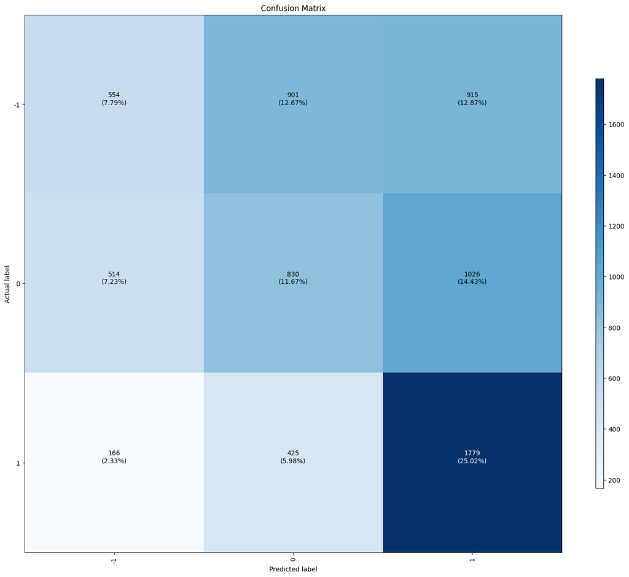